# Surprises in time series analysis

## Australian Pharmaceutical Benefits Scheme

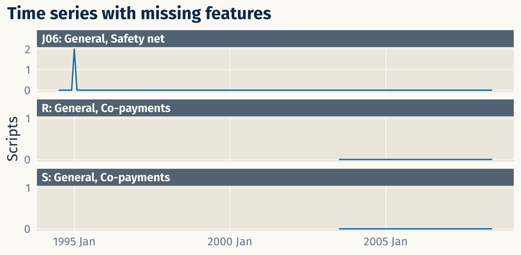

## Australian Pharmaceutical Benefits Scheme

```r
PBS_feat <- PBS_feat |> na.omit()
PBS_prcomp <- PBS_feat |>
  select(where(is.numeric)) |>
  prcomp(scale = TRUE, rank = 2) |>
  augment(PBS_feat)
PBS_prcomp |>
  select(Concession:ATC2, starts_with(".fitted"))
```

```
# A tibble: 333 × 5
  Concession   Type        ATC2  .fittedPC1 .fittedPC2
  <chr>        <chr>       <chr>      <dbl>      <dbl>
1 Concessional Co-payments A01         1.06     0.210
2 Concessional Co-payments A02        -3.20     1.77
3 Concessional Co-payments A03        -1.19     0.931
4 Concessional Co-payments A04         1.21     0.0575
5 Concessional Co-payments A05        -1.44    -1.65
# ℹ 328 more rows
```

## Australian Pharmaceutical Benefits Scheme

[interactive chart not shown]

**J06: Concessional, Safety net**

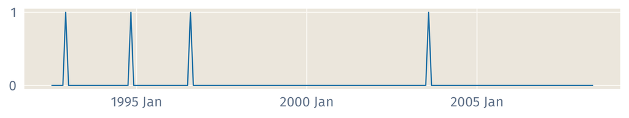

**C05: General, Co-payments**

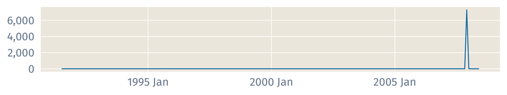

**S02: General, Co-payments**

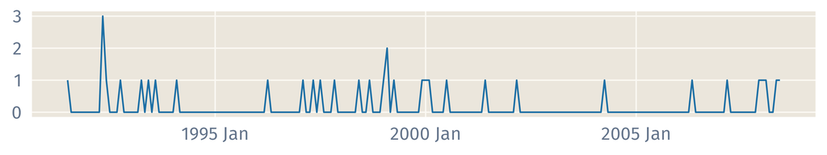

**A15: General, Co-payments**

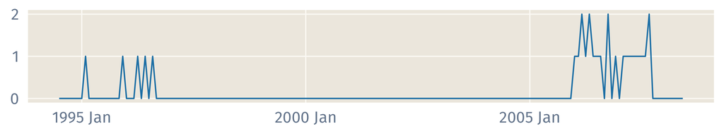

**C09: Concessional, Co-payments**

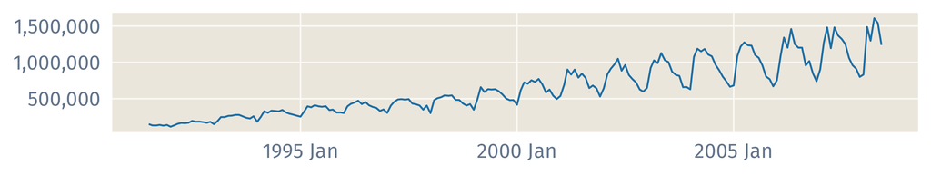

## Kernel density surprisals

KDE

$$\boldsymbol{y}_{i} \in \mathbb{R}^d, \quad \hat{f}(\boldsymbol{y})
= \frac{1}{n} \sum_{i=1}^n |\boldsymbol{H}|^{-1/2} K\big(\boldsymbol{H}^{-1/2}(\boldsymbol{y} - \boldsymbol{y}_i)\big)$$

- $K$: spherically symmetric kernel; $\boldsymbol{H}$: $d \times d$ bandwidth matrix.
- Each observation inflates its own density estimate: use leave-one-out.

LOO KDE values

$$\hat{f}_{-i}(\boldsymbol{y}_i)
= \frac{1}{n - 1} \big( n \hat{f}(\boldsymbol{y}_i) - |\boldsymbol{H}|^{-1/2} K(\boldsymbol{0}) \big)$$

- Surprisals $s_i = -\log \hat{f}_{-i}(\boldsymbol{y}_i)$; probabilities from the GPD.

## Australian Pharmaceutical Benefits Scheme

[interactive chart not shown]

**J06: Concessional, Safety net**

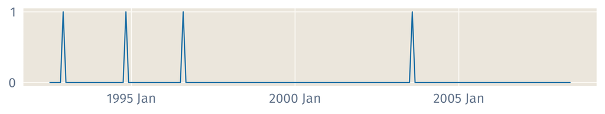

**C05: General, Co-payments**

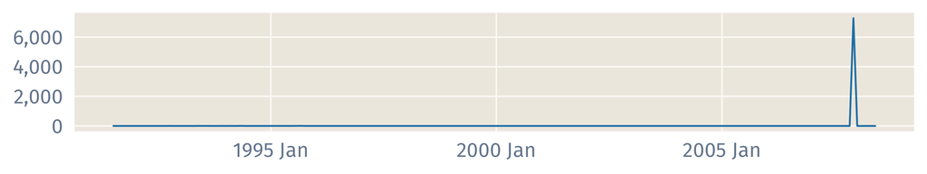

**S02: General, Co-payments**

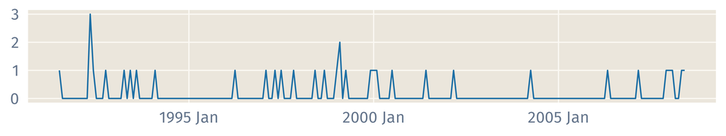

**A15: General, Co-payments**

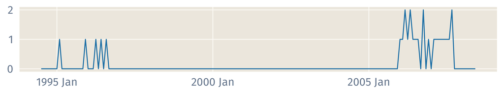

**C09: Concessional, Co-payments**

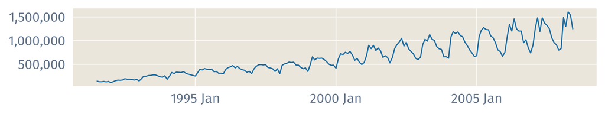

## Australian Pharmaceutical Benefits Scheme

```r
PBS_prcomp |>
  mutate(
    prob = surprisals_prob(
      PBS_prcomp |> select(.fittedPC1, .fittedPC2),
      loo = TRUE,
      approximation = "gpd",
      method = "lookout"
    )
  ) |>
  select(Concession, Type, ATC2, .fittedPC1, .fittedPC2, prob) |>
  arrange(prob) |>
  print(n = 5)
```

```
# A tibble: 333 × 6
  Concession   Type        ATC2  .fittedPC1 .fittedPC2     prob
  <chr>        <chr>       <chr>      <dbl>      <dbl>    <dbl>
1 Concessional Safety net  J06         7.05     -17.9  0
2 General      Co-payments C05         8.51     -23.0  0
3 General      Co-payments S02         5.54     -11.5  0.000444
4 General      Co-payments A15        -1.15      -8.86 0.0200
5 General      Co-payments P03         5.10      -9.70 0.0235
# ℹ 328 more rows
```

## Surveillance

04

1. Surprisals
2. Weird times
3. Weird series
4. Surveillance
5. Summary

## PBS scripts by ATC group

```r
pbs <- PBS |>
  group_by(ATC2) |>
  summarise(Scripts = sum(Scripts) / 1e3) |>
  mutate(t = as.numeric(Month - min(Month) + 1))
```

```
# A tsibble: 17,016 x 4 [1M]
# Key:       ATC2 [84]
   ATC2     Month Scripts     t
   <chr>    <mth>   <dbl> <dbl>
 1 A01   1991 Jul    22.6     1
 2 A01   1991 Aug    20.4     2
 3 A01   1991 Sep    21.4     3
 4 A01   1991 Oct    23.7     4
 5 A01   1991 Nov    23.5     5
 6 A01   1991 Dec    26.3     6
 7 A01   1992 Jan    22.0     7
 8 A01   1992 Feb    16.4     8
 9 A01   1992 Mar    17.2     9
10 A01   1992 Apr    18.8    10
# ℹ 17,006 more rows
```

## Surveillance using forecast distributions

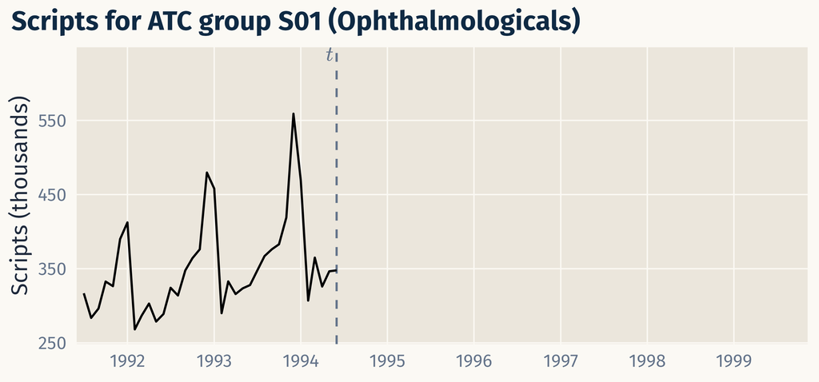

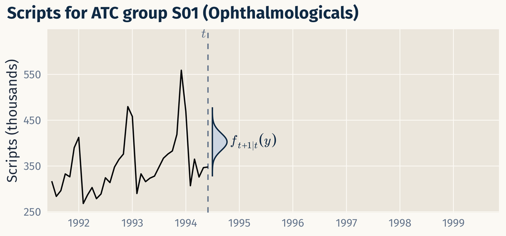

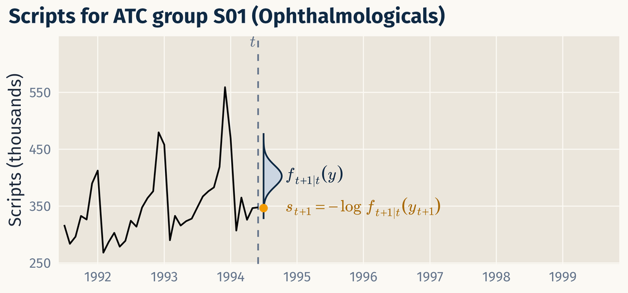

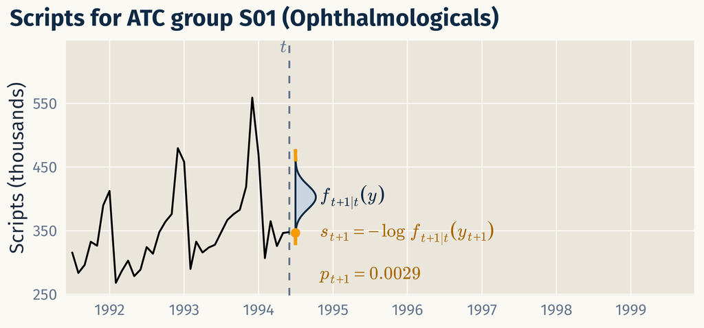

[video not shown]

ETS refitted monthly for every series. Points: $p < 0.01$, $p < 0.001$.

## Surprisal probabilities as p-values

- If $f_{i,t+1|t}$ is the true forecast density, and the surprisal distribution is continuous, then
  $$p_{i,t+1} \mid y_{i,1},\dots,y_{i,t} \sim \text{U}(0,1)$$
  so the $p_{i,t}$ are iid U(0,1) over $t$.
- Thresholding at $\alpha$ gives a false alarm rate of $\alpha$ per series per period.
- Model updated each period, so a level shift is flagged when it happens, then becomes the “new normal”.
- ETS: Gaussian forecast distributions, so $p_{i,t+1}$ is a two-sided $z$-test on the one-step forecast error.

## A first iteration: $t = 36$

```r
pbs_fc <- pbs |>
  filter(t <= 36) |>
  group_by_key() |>
  filter(cumsum(Scripts) > 0, n() >= 36) |>
  ungroup() |>
  model(ets = ETS(Scripts)) |>
  forecast(h = 1)
```

```
# A fable: 82 x 5 [1M]
# Key:     ATC2, .model [82]
  ATC2  .model    Month       Scripts  .mean
  <chr> <chr>     <mth>        <dist>  <dbl>
1 A01   ets    1994 Jul    N(23, 2.1)  23.1
2 A02   ets    1994 Jul  N(590, 1054) 590.
3 A03   ets    1994 Jul     N(84, 19)  84.2
4 A04   ets    1994 Jul     N(69, 15)  69.4
5 A06   ets    1994 Jul    N(33, 4.2)  33.1
6 A07   ets    1994 Jul     N(74, 17)  73.6
7 A09   ets    1994 Jul N(3.7, 0.029)   3.68
# ℹ 75 more rows
```

## A first iteration: $t = 36$

```r
pbs_fc |>
  rename(fcast = Scripts) |>
  left_join(pbs, by = c("ATC2", "Month")) |>
  mutate(prob = surprisals_prob(Scripts, distribution = fcast))
```

```
# A tsibble: 82 x 8 [?]
# Key:       ATC2, .model [82]
   ATC2  .model    Month         fcast  .mean Scripts     t   prob
   <chr> <chr>     <mth>        <dist>  <dbl>   <dbl> <dbl>  <dbl>
 1 A01   ets    1994 Jul    N(23, 2.1)  23.1    20.9     37 0.126
 2 A02   ets    1994 Jul  N(590, 1054) 590.    516.      37 0.0233
 3 A03   ets    1994 Jul     N(84, 19)  84.2    80.5     37 0.393
 4 A04   ets    1994 Jul     N(69, 15)  69.4    66.1     37 0.396
 5 A06   ets    1994 Jul    N(33, 4.2)  33.1    29.2     37 0.0603
 6 A07   ets    1994 Jul     N(74, 17)  73.6    68.5     37 0.223
 7 A09   ets    1994 Jul N(3.7, 0.029)   3.68    3.32    37 0.0313
 8 A10   ets    1994 Jul    N(166, 54) 166.    150.      37 0.0276
 9 A11   ets    1994 Jul      N(30, 3)  30.2    27.8     37 0.156
10 A12   ets    1994 Jul    N(100, 23) 100.0    87.9     37 0.0121
# ℹ 72 more rows
```

## Rolling forward through all series

[figure not shown]

[video not shown]

267 observations with $p_{i,t} < 0.001$, out of 13983.

## Surveillance anomalies

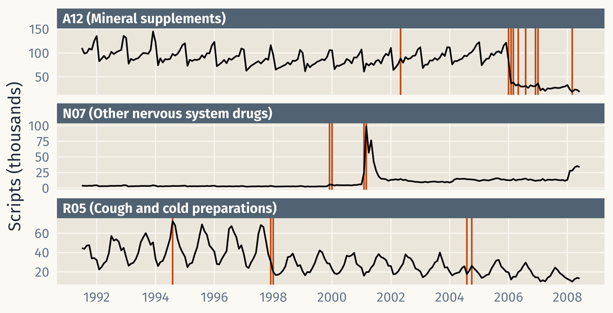

## Surveillance across several series

Some events affect many series at once: mildly unusual in each, very unusual together.

- $M_t$: number of series monitored at time $t$
- $N_t$: number of series with $p_{i,t} < 0.001$
- Independent series: $N_t \sim \text{Binomial}(M_t, \pi)$
- Surprisal probability: $\mathbb{P}(N_t \ge n_t)$
- $\pi = 0.001$ if forecast densities correct
- ETS forecast densities too narrow: actual rate is 0.019
- Solution: estimate $\pi$ from all previous months

## Surveillance across several series

[interactive chart not shown]

## Summary

05

1. Surprisals
2. Weird times
3. Weird series
4. Surveillance
5. Summary

## One idea, three types of surprise

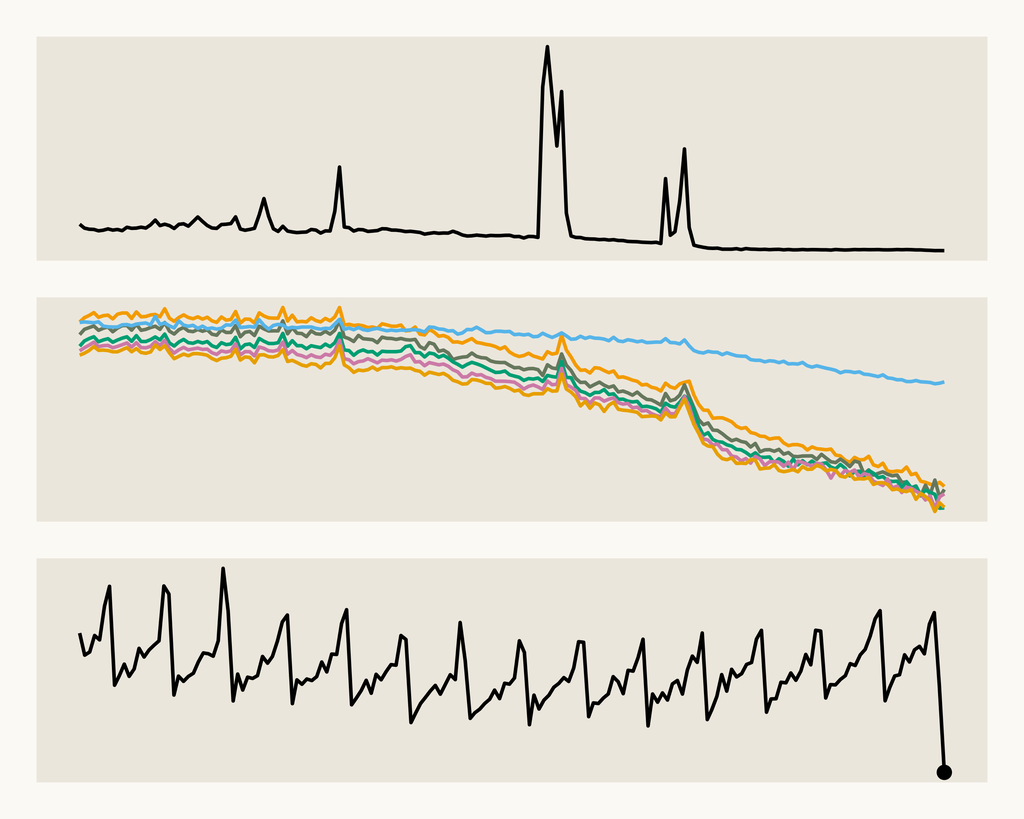

**Weird times**  
$f$: density of residuals from the signal

**Weird series**  
$f$: kernel density of the features

**Surveillance**  
$f$: one-step forecast density

- Surprisal probabilities: $p_t = \mathbb{P}\big(f(Y) \le f(y_t)\big)$
- GPD tail keeps $p_t$ approximately right even when $f$ is wrong

## Coauthors

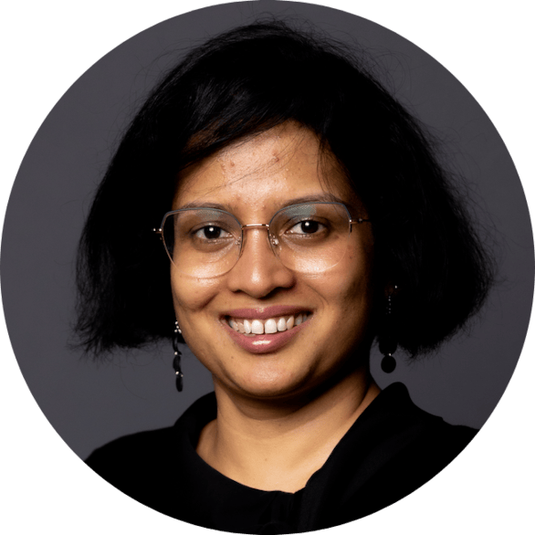

Sevvandi  
Kandanaarachchi  
*CSIRO*

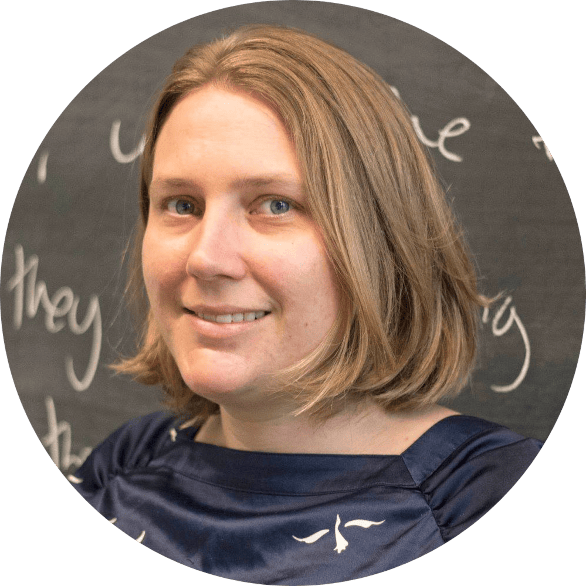

Kate  
Turner  
*ANU*

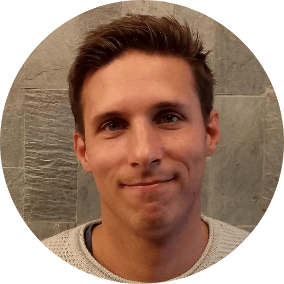

David  
Frazier  
*Monash U*

## Find out more

R package

[figure not shown]

**weird** on CRAN

`install.packages("weird")`

Book

*That’s weird: Anomaly detection using R*

In preparation at  
[`OTexts.com/weird`](https://OTexts.com/weird)

Chapter 11: Time series data

[figure not shown]

Slides, links and related papers:  
[`robjhyndman.com/uconn2026`](https://robjhyndman.com/uconn2026)